# Urban Pedals: Unveiling Toronto’s Bike Share Story

## Overview

This report contains the code and data for a data analysis project focused on exploring the ridership patterns of the bike-share scheme in Toronto. The analysis is conducted using the R programming language to gain insights into user behaviors, popular routes, and temporal trends.

## Data Source

- Ref:
  - https://open.toronto.ca/dataset/bike-share-toronto-ridership-data/

## Download and Import data.

- Import libraries.

```r
# load library
library(opendatatoronto)
library(dplyr)
library(tidyr)
library(ggplot2)
```

- Manually download data files from data source.
  - We have 52 files of 5-year data, from 2019 to 2023.
  - List of all data files

```r
# Define path of dataset
DATA_PATH <- "./source/"

# get the paths for each data file.
FILE_PATH_LIST <- list.files(DATA_PATH, pattern = "\\.csv$", full.names = TRUE)
FILE_PATH_LIST
```

```
 [1] "./source/2019-Q1.csv"                      "./source/2019-Q2.csv"
 [3] "./source/2019-Q3.csv"                      "./source/2019-Q4.csv"
 [5] "./source/2020-01.csv"                      "./source/2020-02.csv"
 [7] "./source/2020-03.csv"                      "./source/2020-04.csv"
 [9] "./source/2020-05.csv"                      "./source/2020-06.csv"
[11] "./source/2020-07.csv"                      "./source/2020-08.csv"
[13] "./source/2020-09.csv"                      "./source/2020-10.csv"
[15] "./source/2020-11.csv"                      "./source/2020-12.csv"
[17] "./source/Bike share ridership 2021-01.csv" "./source/Bike share ridership 2021-02.csv"
[19] "./source/Bike share ridership 2021-03.csv" "./source/Bike share ridership 2021-04.csv"
[21] "./source/Bike share ridership 2021-05.csv" "./source/Bike share ridership 2021-06.csv"
[23] "./source/Bike share ridership 2021-07.csv" "./source/Bike share ridership 2021-08.csv"
[25] "./source/Bike share ridership 2021-09.csv" "./source/Bike share ridership 2021-10.csv"
[27] "./source/Bike share ridership 2021-11.csv" "./source/Bike share ridership 2021-12.csv"
[29] "./source/Bike share ridership 2022-01.csv" "./source/Bike share ridership 2022-02.csv"
[31] "./source/Bike share ridership 2022-03.csv" "./source/Bike share ridership 2022-04.csv"
[33] "./source/Bike share ridership 2022-05.csv" "./source/Bike share ridership 2022-06.csv"
[35] "./source/Bike share ridership 2022-07.csv" "./source/Bike share ridership 2022-08.csv"
[37] "./source/Bike share ridership 2022-09.csv" "./source/Bike share ridership 2022-10.csv"
[39] "./source/Bike share ridership 2022-11.csv" "./source/Bike share ridership 2022-12.csv"
[41] "./source/Bike share ridership 2023-01.csv" "./source/Bike share ridership 2023-02.csv"
[43] "./source/Bike share ridership 2023-03.csv" "./source/Bike share ridership 2023-04.csv"
[45] "./source/Bike share ridership 2023-05.csv" "./source/Bike share ridership 2023-06.csv"
[47] "./source/Bike share ridership 2023-07.csv" "./source/Bike share ridership 2023-08.csv"
[49] "./source/Bike share ridership 2023-09.csv" "./source/Bike share ridership 2023-10.csv"
[51] "./source/Bike share ridership 2023-11.csv" "./source/Bike share ridership 2023-12.csv"
```

- Import data from data files.
  - Check the columns of each csv file for data consisitence.
  - Combine all data into a uniformed dataframe for further anaysis.

```r
# # Apply read.csv, a function to import data from csv file, for each file.
# # Get a list of df
# df_list <- lapply(FILE_PATH_LIST, read.csv)
#
#
# # Union all df by row
# raw_df <- do.call(rbind, df_list)
# raw_df
```

- Test using selective data

```r
# paths <- c(
#   "./source/2019-Q1.csv",
#   "./source/2019-Q2.csv",
#   "./source/2019-Q3.csv",
#   "./source/2019-Q4.csv",
#   "./source/2020-01.csv",
#   "./source/2020-02.csv",
#   "./source/2020-03.csv",
#   "./source/2020-04.csv",
#   "./source/2020-05.csv",
#   "./source/2020-06.csv",
#   "./source/2020-07.csv",
#   "./source/2020-08.csv",
#   "./source/2020-09.csv",
#   "./source/2020-10.csv",
#   "./source/2020-11.csv",
#   "./source/2020-12.csv"
# )
# # paths <- c("./source/2020-01.csv")
# df_list <- lapply(paths, read.csv)
# raw_df <- do.call(rbind, df_list)
# raw_df
```

## Data Processing

### Handling NA and NULL value

- Handle NA value that exist in the raw data

```r
# # Remove rows with any NA values
# proc_NA_df <- raw_df[complete.cases(raw_df), ]
#
# # Remove rows with "NULL" values
# proc_null_df <- proc_NA_df %>%
#   filter(!(End.Station.Name == "NULL" | End.Station.Id == "NULL" | Start.Station.Id =="NULL" | Start.Station.Name == "NULL"))
# proc_df <- proc_null_df
```

### Converting Time-Dimension Data

- Divide time into year, month, date, hour, and minute.

```r
# # Divide "Start.Time" into columns
# proc_df$Start.Time <- as.POSIXct(proc_df$Start.Time, format = "%m/%d/%Y %H:%M")
# proc_df$Start.Year <- as.factor(format(proc_df$Start.Time, "%Y"))
# proc_df$Start.Month <- as.factor(format(proc_df$Start.Time, "%m"))
# proc_df$Start.Date <- as.factor(format(proc_df$Start.Time, "%d"))
# proc_df$Start.Hours <- as.factor(format(proc_df$Start.Time, "%H"))
# proc_df$Start.Minutes <- as.factor(format(proc_df$Start.Time, "%M"))
#
# # Divide "End" into columns
# proc_df$End.Time <- as.POSIXct(proc_df$End.Time, format = "%m/%d/%Y %H:%M")
# proc_df$End.Year <- as.factor(format(proc_df$End.Time, "%Y"))
# proc_df$End.Month <- as.factor(format(proc_df$End.Time, "%m"))
# proc_df$End.Date <- as.factor(format(proc_df$End.Time, "%d"))
# proc_df$End.Hours <- as.factor(format(proc_df$End.Time, "%H"))
# proc_df$End.Minutes <- as.factor(format(proc_df$End.Time, "%M"))
#
# # factor user.type
# proc_df$User.Type <- as.factor(proc_df$User.Type)
#
#
# # Drop Start.Time and End.Time
# proc_df <- proc_df %>% select(-Start.Time, -End.Time)
```

- Check NA value again, in case of any possible values generated during the data processing.

```r
# is_miss <- any(is.na(proc_df))
#
# # if the processed_df contains missing value, drop the rows with missing values and assign to df
# if (is_miss) {
#   df <- proc_df[complete.cases(proc_df), ]
# # otherwise, df = proc_df
# }else{
#   df <- proc_df
# }
#
# is_miss <- any(is.na(df))
# cat("df has missing value? ", is_miss)  # output result
```

- Data Overview after data processing.

```r
# # Data overview after data processing
# num_row <- nrow(df)             # total rows
# column_names <- colnames(df)    # column names
# cat("\n\nNumber of rows: ", "\n", num_row)
# cat("\n\nColumn names: ", "\n", column_names)
#
# cat("\n\nDisplay the Structure:\n")
# str(df)
#
# cat("\n\nDisplay Summaries:\n")
# summary(df)
```

- Preview data

```r
# df
# head(df, 10)
```

### Exporting Processed Data(Optional)

- Export the Processed data to permanently store the processed data.

```r
# # Path to export
# output_file <- "./data/dataset.csv"
# # export
# write.csv(df, file = output_file, row.names = FALSE)
```

### ReLoading Processed Data

```r
data_file <- "./data/dataset.csv"
df <- read.csv(data_file)
df
```

| Trip.Id | Trip..Duration | Start.Station.Id | Start.Station.Name | End.Station.Id | End.Station.Name | Bike.Id | User.Type | Start.Year | Start.Month | Start.Date | Start.Hours | Start.Minutes | End.Year | End.Month | End.Date | End.Hours | End.Minutes |
| --- | --- | --- | --- | --- | --- | --- | --- | --- | --- | --- | --- | --- | --- | --- | --- | --- | --- |
| 4581278 | 1547 | 7021 | Bay St / Albert St | 7233 | King / Cowan Ave - SMART | 1296 | Annual Member | 2019 | 1 | 1 | 0 | 8 | 2019 | 1 | 1 | 0 | 33 |
| 4581279 | 1112 | 7160 | King St W / Tecumseth St | 7051 | Wellesley St E / Yonge St (Green P) | 2947 | Annual Member | 2019 | 1 | 1 | 0 | 10 | 2019 | 1 | 1 | 0 | 29 |
| 4581280 | 589 | 7055 | Jarvis St / Carlton St | 7013 | Scott St / The Esplanade | 2293 | Annual Member | 2019 | 1 | 1 | 0 | 15 | 2019 | 1 | 1 | 0 | 25 |
| 4581281 | 259 | 7012 | Elizabeth St / Edward St (Bus Terminal) | 7235 | Bay St / College St (West Side) - SMART | 283 | Annual Member | 2019 | 1 | 1 | 0 | 16 | 2019 | 1 | 1 | 0 | 20 |
| 4581282 | 281 | 7041 | Edward St / Yonge St | 7257 | Dundas St W / St. Patrick St | 1799 | Annual Member | 2019 | 1 | 1 | 0 | 19 | 2019 | 1 | 1 | 0 | 24 |
| 4581283 | 624 | 7041 | Edward St / Yonge St | 7031 | Jarvis St / Isabella St | 661 | Annual Member | 2019 | 1 | 1 | 0 | 26 | 2019 | 1 | 1 | 0 | 36 |
| 4581284 | 604 | 7041 | Edward St / Yonge St | 7031 | Jarvis St / Isabella St | 2120 | Annual Member | 2019 | 1 | 1 | 0 | 26 | 2019 | 1 | 1 | 0 | 36 |
| 4581285 | 416 | 7275 | Queen St W / James St | 7041 | Edward St / Yonge St | 3187 | Annual Member | 2019 | 1 | 1 | 0 | 26 | 2019 | 1 | 1 | 0 | 33 |
| 4581286 | 192 | 7071 | 161 Bleecker St (South of Wellesley) | 7311 | Sherbourne St / Isabella St | 3026 | Annual Member | 2019 | 1 | 1 | 0 | 34 | 2019 | 1 | 1 | 0 | 37 |
| 4581287 | 518 | 7199 | College St / Markham St | 7252 | Robert St / Bloor St W - SMART | 1597 | Annual Member | 2019 | 1 | 1 | 0 | 38 | 2019 | 1 | 1 | 0 | 46 |

[output cut: 990 more lines]

- Data Overview afater loading data.

```r
# Data overview after data processing
num_row <- nrow(df)             # total rows
column_names <- colnames(df)    # column names
cat("\n\nNumber of rows: ", "\n", num_row)
```

```
Number of rows:
 17789237
```

```r
cat("\n\nColumn names: ", "\n", column_names)
```

```
Column names:
 Trip.Id Trip..Duration Start.Station.Id Start.Station.Name End.Station.Id End.Station.Name Bike.Id User.Type Start.Year Start.Month Start.Date Start.Hours Start.Minutes End.Year End.Month End.Date End.Hours End.Minutes
```

```r
cat("\n\nDisplay the Structure:\n")
```

```
Display the Structure:
```

```r
str(df)
```

```
'data.frame':   17789237 obs. of  18 variables:
 $ Trip.Id           : num  4581278 4581279 4581280 4581281 4581282 ...
 $ Trip..Duration    : int  1547 1112 589 259 281 624 604 416 192 518 ...
 $ Start.Station.Id  : int  7021 7160 7055 7012 7041 7041 7041 7275 7071 7199 ...
 $ Start.Station.Name: chr  "Bay St / Albert St" "King St W / Tecumseth St" "Jarvis St / Carlton St" "Elizabeth St / Edward St (Bus Terminal)" ...
 $ End.Station.Id    : int  7233 7051 7013 7235 7257 7031 7031 7041 7311 7252 ...
 $ End.Station.Name  : chr  "King / Cowan Ave - SMART" "Wellesley St E / Yonge St (Green P)" "Scott St / The Esplanade" "Bay St / College St (West Side) - SMART" ...
 $ Bike.Id           : chr  "1296" "2947" "2293" "283" ...
 $ User.Type         : chr  "Annual Member" "Annual Member" "Annual Member" "Annual Member" ...
 $ Start.Year        : int  2019 2019 2019 2019 2019 2019 2019 2019 2019 2019 ...
 $ Start.Month       : int  1 1 1 1 1 1 1 1 1 1 ...
 $ Start.Date        : int  1 1 1 1 1 1 1 1 1 1 ...
 $ Start.Hours       : int  0 0 0 0 0 0 0 0 0 0 ...
 $ Start.Minutes     : int  8 10 15 16 19 26 26 26 34 38 ...
 $ End.Year          : int  2019 2019 2019 2019 2019 2019 2019 2019 2019 2019 ...
 $ End.Month         : int  1 1 1 1 1 1 1 1 1 1 ...
 $ End.Date          : int  1 1 1 1 1 1 1 1 1 1 ...
 $ End.Hours         : int  0 0 0 0 0 0 0 0 0 0 ...
 $ End.Minutes       : int  33 29 25 20 24 36 36 33 37 46 ...
```

```r
cat("\n\nDisplay Summaries:\n")
```

```
Display Summaries:
```

```r
summary(df)
```

```
    Trip.Id         Trip..Duration     Start.Station.Id Start.Station.Name End.Station.Id
 Min.   : 4581278   Min.   :       0   Min.   :7000     Length:17789237    Min.   :7000
 1st Qu.: 9607762   1st Qu.:     439   1st Qu.:7078     Class :character   1st Qu.:7077
 Median :14783657   Median :     729   Median :7227     Mode  :character   Median :7224
 Mean   :15075490   Mean   :    1047   Mean   :7246                        Mean   :7243
 3rd Qu.:20359050   3rd Qu.:    1164   3rd Qu.:7383                        3rd Qu.:7381
 Max.   :26682738   Max.   :12403785   Max.   :7681                        Max.   :7681
 End.Station.Name     Bike.Id           User.Type           Start.Year    Start.Month
 Length:17789237    Length:17789237    Length:17789237    Min.   :2019   Min.   : 1.000
 Class :character   Class :character   Class :character   1st Qu.:2020   1st Qu.: 6.000
 Mode  :character   Mode  :character   Mode  :character   Median :2021   Median : 7.000
                                                          Mean   :2021   Mean   : 7.246
                                                          3rd Qu.:2023   3rd Qu.: 9.000
                                                          Max.   :2023   Max.   :12.000
   Start.Date     Start.Hours    Start.Minutes      End.Year      End.Month         End.Date
 Min.   : 1.00   Min.   : 0.00   Min.   : 0.00   Min.   :2019   Min.   : 1.000   Min.   : 1.00
 1st Qu.: 8.00   1st Qu.:11.00   1st Qu.:14.00   1st Qu.:2020   1st Qu.: 6.000   1st Qu.: 8.00
 Median :16.00   Median :15.00   Median :30.00   Median :2021   Median : 7.000   Median :16.00
 Mean   :15.73   Mean   :14.57   Mean   :29.55   Mean   :2021   Mean   : 7.246   Mean   :15.73
 3rd Qu.:23.00   3rd Qu.:18.00   3rd Qu.:45.00   3rd Qu.:2023   3rd Qu.: 9.000   3rd Qu.:23.00
 Max.   :31.00   Max.   :23.00   Max.   :59.00   Max.   :2024   Max.   :12.000   Max.   :31.00
   End.Hours      End.Minutes
 Min.   : 0.00   Min.   : 0.00
 1st Qu.:11.00   1st Qu.:15.00
 Median :16.00   Median :30.00
 Mean   :14.71   Mean   :29.79
 3rd Qu.:18.00   3rd Qu.:45.00
 Max.   :23.00   Max.   :59.00
```

- Preview data

```r
# df
head(df, 10)
```

|  | Trip.Id | Trip..Duration | Start.Station.Id | Start.Station.Name | End.Station.Id | End.Station.Name | Bike.Id | User.Type | Start.Year | Start.Month | Start.Date | Start.Hours | Start.Minutes | End.Year | End.Month | End.Date | End.Hours | End.Minutes |
| --- | --- | --- | --- | --- | --- | --- | --- | --- | --- | --- | --- | --- | --- | --- | --- | --- | --- | --- |
| 1 | 4581278 | 1547 | 7021 | Bay St / Albert St | 7233 | King / Cowan Ave - SMART | 1296 | Annual Member | 2019 | 1 | 1 | 0 | 8 | 2019 | 1 | 1 | 0 | 33 |
| 2 | 4581279 | 1112 | 7160 | King St W / Tecumseth St | 7051 | Wellesley St E / Yonge St (Green P) | 2947 | Annual Member | 2019 | 1 | 1 | 0 | 10 | 2019 | 1 | 1 | 0 | 29 |
| 3 | 4581280 | 589 | 7055 | Jarvis St / Carlton St | 7013 | Scott St / The Esplanade | 2293 | Annual Member | 2019 | 1 | 1 | 0 | 15 | 2019 | 1 | 1 | 0 | 25 |
| 4 | 4581281 | 259 | 7012 | Elizabeth St / Edward St (Bus Terminal) | 7235 | Bay St / College St (West Side) - SMART | 283 | Annual Member | 2019 | 1 | 1 | 0 | 16 | 2019 | 1 | 1 | 0 | 20 |
| 5 | 4581282 | 281 | 7041 | Edward St / Yonge St | 7257 | Dundas St W / St. Patrick St | 1799 | Annual Member | 2019 | 1 | 1 | 0 | 19 | 2019 | 1 | 1 | 0 | 24 |
| 6 | 4581283 | 624 | 7041 | Edward St / Yonge St | 7031 | Jarvis St / Isabella St | 661 | Annual Member | 2019 | 1 | 1 | 0 | 26 | 2019 | 1 | 1 | 0 | 36 |
| 7 | 4581284 | 604 | 7041 | Edward St / Yonge St | 7031 | Jarvis St / Isabella St | 2120 | Annual Member | 2019 | 1 | 1 | 0 | 26 | 2019 | 1 | 1 | 0 | 36 |
| 8 | 4581285 | 416 | 7275 | Queen St W / James St | 7041 | Edward St / Yonge St | 3187 | Annual Member | 2019 | 1 | 1 | 0 | 26 | 2019 | 1 | 1 | 0 | 33 |
| 9 | 4581286 | 192 | 7071 | 161 Bleecker St (South of Wellesley) | 7311 | Sherbourne St / Isabella St | 3026 | Annual Member | 2019 | 1 | 1 | 0 | 34 | 2019 | 1 | 1 | 0 | 37 |
| 10 | 4581287 | 518 | 7199 | College St / Markham St | 7252 | Robert St / Bloor St W - SMART | 1597 | Annual Member | 2019 | 1 | 1 | 0 | 38 | 2019 | 1 | 1 | 0 | 46 |

## Trip analysis

### Yearly Trip Trends

```r
trip_yearly <- df %>%
  group_by(Year = Start.Year) %>%
  summarize(Trip = n())
trip_yearly
```

| Year | Trip |
| --- | --- |
| 2019 | 2439047 |
| 2020 | 2908239 |
| 2021 | 3565746 |
| 2022 | 4266232 |
| 2023 | 4609973 |

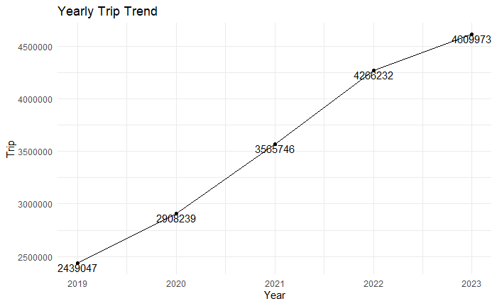

```r
ggplot(
  data = trip_yearly,
  mapping = aes(
      x = Year,
      y = Trip,
      group = 1
  )
) +
  geom_line() +
  geom_point() +
  geom_text(aes(label = as.character(Trip)), vjust = 1, hjust = 0.5) +
  labs(
    title = "Yearly Trip Trend",
    x = "Year",
    y = "Trip"
  ) +
  theme_minimal()
```

### Monthly Trip Distribution

- Comparing monthly trip to unveil patterns over the months

```r
trip_monthly_across_year <- df %>%
  group_by(
    Year = Start.Year,
    Month = Start.Month
    ) %>%
  summarize(Trip = n())
trip_monthly_across_year
```

| Year | Month | Trip |
| --- | --- | --- |
| 2019 | 1 | 61461 |
| 2019 | 2 | 40055 |
| 2019 | 3 | 87540 |
| 2019 | 4 | 145150 |
| 2019 | 5 | 214613 |
| 2019 | 6 | 291917 |
| 2019 | 7 | 382235 |
| 2019 | 8 | 417393 |
| 2019 | 9 | 330703 |
| 2019 | 10 | 248467 |

[output cut: 50 more lines]

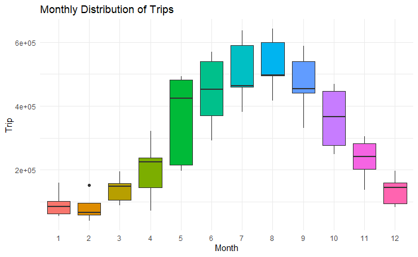

```r
ggplot(
  data = trip_monthly_across_year,
  mapping = aes(
    x = factor(Month),
    y = Trip,
    fill = factor(Month)
    )
  ) +
  geom_boxplot(show.legend = FALSE) +
  labs(
    title = "Monthly Distribution of Trips",
    x = "Month",
    y = "Trip",
    fill = "Month"
  ) +
  theme_minimal()
```

### Hourly Trip Pattern

- Exploring Patterns Throughout the Day

```r
trip_hourly_across_month <- df %>%
  group_by(
    Month = Start.Month,
    Hour = Start.Hours
    ) %>%
  summarize(Trip = n())
trip_hourly_across_month
```

| Month | Hour | Trip |
| --- | --- | --- |
| 1 | 0 | 4571 |
| 1 | 1 | 3076 |
| 1 | 2 | 2324 |
| 1 | 3 | 1436 |
| 1 | 4 | 1403 |
| 1 | 5 | 2635 |
| 1 | 6 | 7521 |
| 1 | 7 | 17508 |
| 1 | 8 | 37136 |
| 1 | 9 | 27818 |

[output cut: 278 more lines]

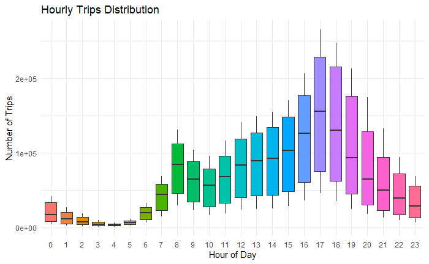

```r
ggplot(
  trip_hourly_across_month,
  aes(
    x = factor(Hour),
    y = Trip,
    fill = factor(Hour)
    )
  ) +
  geom_boxplot(show.legend = FALSE) +
  labs(
    title = "Hourly Trips Distribution",
    x = "Hour of Day",
    y = "Number of Trips",
    fill = "Hour of Day") +
  theme_minimal()
```

## Duration Analysis

### Duration Yearly Trend

```r
duration_yearly <- df %>%
  group_by(Year = Start.Year) %>%
  summarize(Mean_Duration = round(mean(Trip..Duration) / 60, 2))

duration_yearly
```

| Year | Mean_Duration |
| --- | --- |
| 2019 | 17.39 |
| 2020 | 19.38 |
| 2021 | 17.27 |
| 2022 | 16.00 |
| 2023 | 17.74 |

```r
NA
```

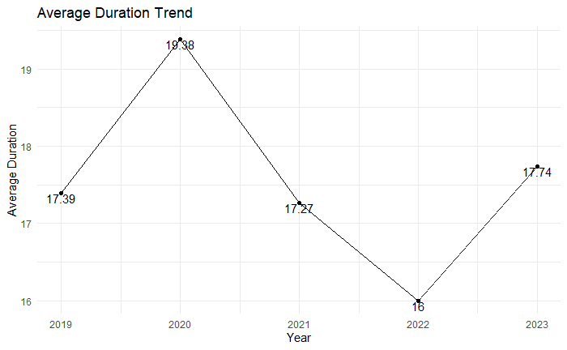

```r
ggplot(
  data = duration_yearly,
  mapping = aes(
      x = Year,
      y = Mean_Duration,
      group = 1
    )
  ) +
  geom_line() +
  geom_point() +
  geom_text(
    aes(
      label = as.character(Mean_Duration)
      ),
    vjust = 1,
    hjust = 0.5
  ) +
  labs(
    title = "Average Duration Trend",
    x = "Year",
    y = "Average Duration"
  ) +
  theme_minimal()
```

### Duration Pattern over Months

```r
duration_monthly_across_year <- df %>%
  group_by(
    Year = Start.Year,
    Month = Start.Month) %>%
  summarize(Mean_Duration = round(mean(Trip..Duration) / 60, 2))  # Convert mean to minutes
duration_monthly_across_year
```

| Year | Month | Mean_Duration |
| --- | --- | --- |
| 2019 | 1 | 12.96 |
| 2019 | 2 | 14.41 |
| 2019 | 3 | 13.20 |
| 2019 | 4 | 15.45 |
| 2019 | 5 | 16.69 |
| 2019 | 6 | 19.56 |
| 2019 | 7 | 18.82 |
| 2019 | 8 | 19.75 |
| 2019 | 9 | 16.67 |
| 2019 | 10 | 16.11 |

[output cut: 50 more lines]

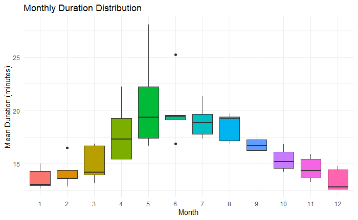

```r
ggplot(
  data = duration_monthly_across_year,
  mapping = aes(
    x = factor(Month),
    y = Mean_Duration,
    fill = factor(Month)
    )
  ) +
  geom_boxplot(show.legend = FALSE) +
  labs(
    title = "Monthly Duration Distribution",
    x = "Month",
    y = "Mean Duration (minutes)"
  ) +
  theme_minimal()
```

### Duration Pattern throughout A Day

```r
duration_hourly_across_month <- df %>%
  group_by(
    Month = Start.Month,
    Hour = Start.Hours
    ) %>%
  summarize(Mean_Duration = round(mean(Trip..Duration) / 60, 2))  # Convert mean to minutes
duration_hourly_across_month
```

| Month | Hour | Mean_Duration |
| --- | --- | --- |
| 1 | 0 | 13.33 |
| 1 | 1 | 16.31 |
| 1 | 2 | 24.04 |
| 1 | 3 | 33.38 |
| 1 | 4 | 13.05 |
| 1 | 5 | 12.86 |
| 1 | 6 | 12.74 |
| 1 | 7 | 12.37 |
| 1 | 8 | 12.19 |
| 1 | 9 | 12.71 |

[output cut: 278 more lines]

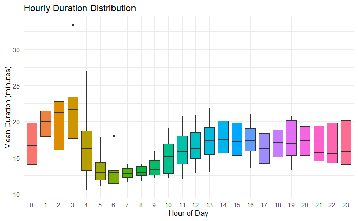

```r
ggplot(
  data = duration_hourly_across_month,
  mapping = aes(
    x = factor(Hour),
    y = Mean_Duration,
    fill = factor(Hour)
    )
  ) +
  geom_boxplot(show.legend = FALSE) +
  labs(
    title = "Hourly Duration Distribution",
    x = "Hour of Day",
    y = "Mean Duration (minutes)"
  ) +
  theme_minimal()
```

## Geolocation Analysis

### Hot Start Locations

#### Hot start spot (Top 10)

```r
hot_start_spot <- df %>%
  group_by(Start.Station.Name) %>%
  summarize(Total_Trips = n()) %>%
  arrange(desc(Total_Trips)) %>%
  slice_head(n = 10)
hot_start_spot
```

| Start.Station.Name | Total_Trips |
| --- | --- |
| York St / Queens Quay W | 167820 |
| Bay St / Queens Quay W (Ferry Terminal) | 129723 |
| Bay St / College St (East Side) | 124516 |
| Queens Quay E / Lower Sherbourne St | 114306 |
| HTO Park (Queens Quay W) | 111224 |
| Lake Shore Blvd W / Ontario Dr | 111058 |
| Bay St / Wellesley St W | 109131 |
| Ontario Place Blvd / Lake Shore Blvd W (East) | 109044 |
| Bathurst St/Queens Quay(Billy Bishop Airport) | 108858 |
| Dundas St E / Regent Park Blvd | 105913 |

```r
NA
```

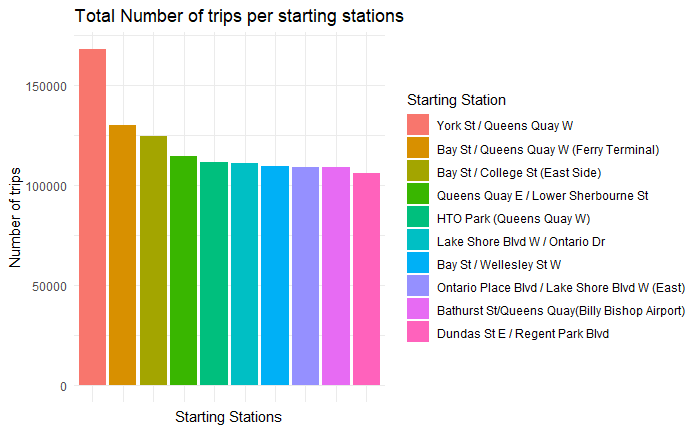

```r
ggplot(
  data = hot_start_spot,
  mapping = aes(
      x = reorder(Start.Station.Name, -Total_Trips),
      y = Total_Trips,
      fill = reorder(Start.Station.Name, -Total_Trips)
      )
  ) +
  geom_bar(
    stat = "identity"
  ) +
  labs(
    title = "Total Number of trips per starting stations",
    x = "Starting Stations",
    y = "Number of trips",
    fill = "Starting Station"
  ) +
  theme_minimal()+
  theme(axis.text.x = element_blank())
```

```r
NA
NA
```

#### Hot start street (Top 10)

```r
library(stringr)

hot_start_streets <- df %>%
  separate_rows(Start.Station.Name, sep = " / ") %>% # Separate the station names
  mutate(Start.Station.Street = Start.Station.Name) %>%
  group_by(Start.Station.Street) %>%
  summarize(Total_Trips = n()) %>%
  arrange(desc(Total_Trips)) %>%
  slice_head(n = 10)
hot_start_streets
```

| Start.Station.Street | Total_Trips |
| --- | --- |
| Yonge St | 905277 |
| Queen St W | 777197 |
| Bay St | 754436 |
| Bloor St W | 648682 |
| King St W | 630577 |
| Dundas St W | 596545 |
| College St | 507797 |
| Spadina Ave | 430988 |
| Dundas St E | 393854 |
| Adelaide St W | 391302 |

```r
NA
```

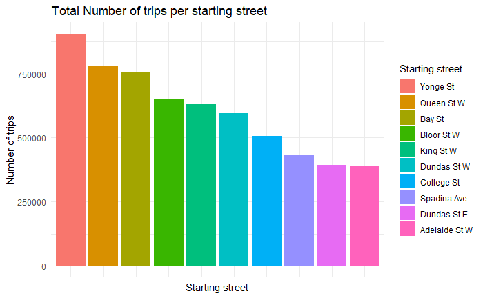

```r
ggplot(
  data = hot_start_streets,
  mapping = aes(
      x = reorder(Start.Station.Street, -Total_Trips),
      y = Total_Trips,
      fill = reorder(Start.Station.Street, -Total_Trips)
      )
  ) +
  geom_bar(
    stat = "identity"
  ) +
  labs(
    title = "Total Number of trips per starting street",
    x = "Starting street",
    y = "Number of trips",
    fill = "Starting street"
  ) +
  theme_minimal()+
  theme(axis.text.x = element_blank())
```

### Hot End Locations

#### Hot End spot (Top 10)

```r
hot_end_spot <- df %>%
  group_by(End.Station.Name) %>%
  summarize(Total_Trips = n()) %>%
  arrange(desc(Total_Trips)) %>%
  slice_head(n = 10)
hot_end_spot
```

| End.Station.Name | Total_Trips |
| --- | --- |
| York St / Queens Quay W | 191618 |
| Bay St / Queens Quay W (Ferry Terminal) | 137039 |
| Union Station | 134622 |
| Bay St / College St (East Side) | 125581 |
| HTO Park (Queens Quay W) | 125254 |
| Bathurst St/Queens Quay(Billy Bishop Airport) | 121870 |
| Queens Quay E / Lower Sherbourne St | 119303 |
| Queens Quay / Yonge St | 114252 |
| Dundas St W / Yonge St | 113685 |
| Lake Shore Blvd W / Ontario Dr | 110234 |

```r
NA
```

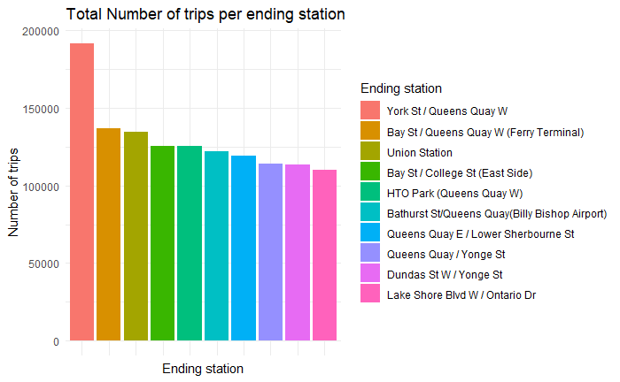

```r
ggplot(
  data = hot_end_spot,
  mapping = aes(
      x = reorder(End.Station.Name, -Total_Trips),
      y = Total_Trips,
      fill = reorder(End.Station.Name, -Total_Trips)
      )
  ) +
  geom_bar(
    stat = "identity"
  ) +
  labs(
    title = "Total Number of trips per ending station",
    x = "Ending station",
    y = "Number of trips",
    fill = "Ending station"
  ) +
  theme_minimal()+
  theme(axis.text.x = element_blank())
```

#### Hot end street (Top 10)

```r
hot_end_streets <- df %>%
  separate_rows(End.Station.Name, sep = " / ") %>% # Separate the station names
  mutate(End.Station.Street = End.Station.Name) %>%
  group_by(End.Station.Street) %>%
  summarize(Total_Trips = n()) %>%
  arrange(desc(Total_Trips)) %>%
  slice_head(n = 10)
hot_end_streets
```

| End.Station.Street | Total_Trips |
| --- | --- |
| Yonge St | 878065 |
| Queen St W | 827472 |
| Bay St | 720596 |
| King St W | 692586 |
| Bloor St W | 605196 |
| Dundas St W | 601900 |
| College St | 501619 |
| Spadina Ave | 424328 |
| Adelaide St W | 409449 |
| Dundas St E | 406959 |

```r
NA
NA
```

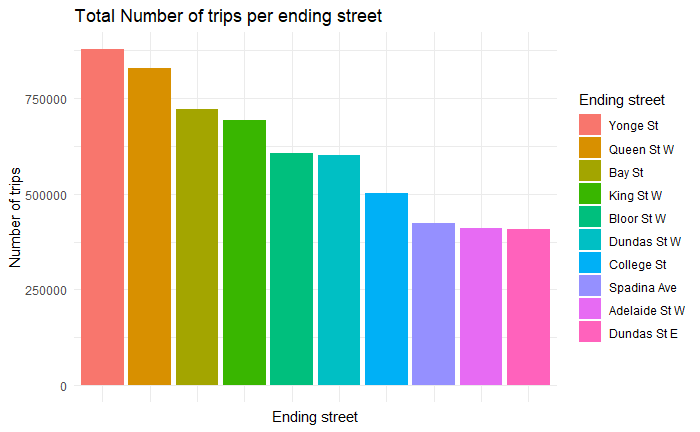

```r
ggplot(
  data = hot_end_streets,
  mapping = aes(
      x = reorder(End.Station.Street, -Total_Trips),
      y = Total_Trips,
      fill = reorder(End.Station.Street, -Total_Trips)
      )
  ) +
  geom_bar(
    stat = "identity"
  ) +
  labs(
    title = "Total Number of trips per ending street",
    x = "Ending street",
    y = "Number of trips",
    fill = "Ending street"
  ) +
  theme_minimal()+
  theme(axis.text.x = element_blank())
```

### Hot Trips (Top 10)

```r
hot_trip <- df %>%
  mutate(Trip.Spots = paste(Start.Station.Name, End.Station.Name, sep =" -> ")) %>%
  group_by(Trip.Spots) %>%
  summarize(Total_Trips = n()) %>%
  arrange(desc(Total_Trips)) %>%
  slice_head(n = 10)
hot_trip
```

| Trip.Spots | Total_Trips |
| --- | --- |
| Tommy Thompson Park (Leslie Street Spit) -> Tommy Thompson Park (Leslie Street Spit) | 37385 |
| Ontario Place Blvd / Lake Shore Blvd W (East) -> Ontario Place Blvd / Lake Shore Blvd W (East) | 13764 |
| Humber Bay Shores Park West -> Humber Bay Shores Park West | 13181 |
| Bay St / Queens Quay W (Ferry Terminal) -> Bay St / Queens Quay W (Ferry Terminal) | 12383 |
| HTO Park (Queens Quay W) -> HTO Park (Queens Quay W) | 12291 |
| York St / Queens Quay W -> York St / Queens Quay W | 11914 |
| Cherry Beach -> Tommy Thompson Park (Leslie Street Spit) | 10761 |
| Humber Bay Shores Park / Marine Parade Dr -> Humber Bay Shores Park / Marine Parade Dr | 10602 |
| Tommy Thompson Park (Leslie Street Spit) -> Cherry Beach | 9596 |
| Humber Bay Shores Park East -> Humber Bay Shores Park East | 9117 |

```r
NA
NA
```

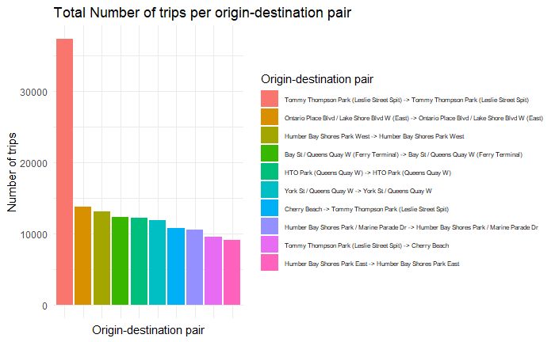

```r
ggplot(
  data = hot_trip,
  mapping = aes(
      x = reorder(Trip.Spots, -Total_Trips),
      y = Total_Trips,
      fill = reorder(Trip.Spots, -Total_Trips)
      )
  ) +
  geom_bar(
    stat = "identity"
  ) +
  labs(
    title = "Total Number of trips per origin-destination pair",
    x = "Origin-destination pair",
    y = "Number of trips",
    fill = "Origin-destination pair"
  ) +
  theme_minimal()+
  theme(axis.text.x = element_blank()  ,
        legend.text = element_text(size = 6))
```

## Shiny Rendering

```r
library(shiny)
library(ggplot2)

ui <- fluidPage(
  tags$head(
    tags$style(HTML("
      #sidebar {
        position: fixed;
        top: 0;
        left: 0;
        bottom: 0;
        width: 300px; /* Set your desired width */
        background-color: #f8f9fa; /* Set your desired background color */
        padding: 10px;

      },
      #mainPanel {
        font-size: 24px;
        padding-right: 200px;
      }
    "))
  ),

  sidebarLayout(
    sidebarPanel(
      id = "sidebar",
      tags$div(
        tags$h3("Shared-bike Trip Analysis"),
        tags$ul(
          tags$li(
            tags$a(href = "#source", "Data Source")
          ),
          tags$li(
            tags$a(href = "#processing", "Data Processing")
          ),
          # Trip
          tags$li(
            tags$a(href = "#trip", "Trip Analysis"),
            tags$ul(
              tags$li(tags$a(href = "#yearly-trip", "Yearly Trends")),
              tags$li(tags$a(href = "#monthly-trip", "The Pattern over Months")),
              tags$li(tags$a(href = "#hourly-trip", "The Pattern throughout A Day"))
            )
          ),
          # duration
          tags$li(tags$a(href = "#duration", "Duration Analysis"),
                  tags$ul(
                    tags$li(tags$a(href = "#yearly-duration", "Yearly Trend")),
                    tags$li(tags$a(href = "#monthly-duration", "The Pattern over Months")),
                    tags$li(tags$a(href = "#hourly-duration", "The Pattern throughout A Day"))
                  )
          ),
          # location
          tags$li(tags$a(href = "#location", "Location Analysis"),
                  tags$ul(
                    tags$li(tags$a(href = "#start-street", "Count of start street")),
                    tags$li(tags$a(href = "#end-street", "Count of end street")),
                    tags$li(tags$a(href = "#trip-pairs", "Count of trip pairs"))
                  )
          )
        )
      )
    ),
    mainPanel(
      style = "padding-right: 100px; text-align: left;",

      h1("Urban Pedals:", align = "center"),
      h3("Unveiling Toronto’s Bike Share Story", align = "center"),
      h2("Data Source", id = "source"),
      div(
        style = "font-size: 18px",
        p("Historical Bike Share Toronto ridership data."),
        p("Ref: ",tags$a(href ="https://open.toronto.ca/dataset/bike-share-toronto-ridership-data/", "Toronto Open Data")
        ),
      ),
      tags$hr(),
      div(style = "height: 50px"),

      # data processing
      h2("Data Processing", id = "processing"),
      div(
        style = "font-size: 18px",
        p("Handle NA and 'NULL' Value"),
        p("Data Overview:"),
      ),
      br(),
      imageOutput("photo"),
      tags$hr(),

      # Trip Analysis
      h2("Trip analysis", id = "trip"),
      h3("Yearly Trends", id = "yearly-trip"),
      tableOutput('trip_yearly_tb'),
      br(),
      plotOutput("trip_yearly_plot"),
      br(),
      div(
        style = "font-size: 24px;",
        p("The annual trip count exhibits a consistent upward trend, doubling from approximately 2.4 million to 4.6 million over the specified period.")
        ),
      tags$hr(),

      # trip monlty
      h3("The Pattern over Months", id = "monthly-trip"),
      br(),
      DT::dataTableOutput("trip_monthly_tb"),
      br(),
      plotOutput("trip_monthly_plot"),
      div(
        style = "font-size: 24px;",
        # description
        p("")
        ),
      tags$hr(style = "padding-bottom: 50px"),

      # trip hourly
      h3("The Pattern throughout A Day", id = "hourly-trip"),
      br(),
      DT::dataTableOutput("trip_hourly_tb"),
      br(),
      plotOutput("trip_hourly_plot"),
      div(
        style = "font-size: 24px;",
        # description
        p("")
        ),
      tags$hr(),

      # Duration
      h2("Duration Analysis", id = "duration"),

      # duration yearly
      h3("Yearly Trend", id = "yearly-duration"),
      br(),
      DT::dataTableOutput("duration_yearly_tb"),
      br(),
      plotOutput("duration_yearly_plot"),
      div(
        style = "font-size: 24px;",
        # description
        p("")
        ),
      tags$hr(),

      # duration monthly
      h3("The Pattern over Months", id = "monthly-duration"),
      br(),
      DT::dataTableOutput("duration_monthly_tb"),
      br(),
      plotOutput("duration_monthly_plot"),
      div(
        style = "font-size: 24px;",
        # description
        p("")
        ),
      tags$hr(),

      # duration hourly
      h3("The Pattern throughout A Day", id = "hourly-duration"),
      br(),
      DT::dataTableOutput("duration_hourly_tb"),
      br(),
      plotOutput("duration_hourly_plot"),
      div(
        style = "font-size: 24px;",
        # description
        p("")
        ),
      tags$hr(),


      # Location
      h2("Location Analysis", id = "location"),

      # location start street
      h3("Total Number of trips per starting stations", id = "start-street"),
      br(),
      DT::dataTableOutput("hot_start_streets_tb"),
      br(),
      plotOutput("hot_start_streets_plot"),
      div(
        style = "font-size: 24px;",
        # description
        p("")
        ),
      tags$hr(),

      # location end street
      h3("Total Number of trips per ending street", id = "end-street"),
      br(),
      DT::dataTableOutput("hot_end_streets_tb"),
      br(),
      plotOutput("hot_end_streets_plot"),
      div(
        style = "font-size: 24px;",
        # description
        p("")
        ),
      tags$hr(),

      # location pairs
      h3("Total Number of trips per origin-destination pair", id = "trip-pairs"),
      br(),
      DT::dataTableOutput("hot_trip_tb"),
      br(),
      plotOutput("hot_trip_plot"),
      div(
        style = "font-size: 24px;",
        # description
        p("")
        ),
      tags$hr(),


    )
  )
)

server <- function(input, output) {

  output$photo <- renderImage({
    list(
      src = file.path("info.png"),
      contentType = "image/png",
      width = 800
      )
  }, deleteFile = FALSE)

  # trip yearly
  output$trip_yearly_tb <- renderTable(trip_yearly)
  output$trip_yearly_plot <- renderPlot({
    ggplot(
     data = trip_yearly,
     mapping = aes(
     x = Year,
     y = Trip,
     group = 1
     )
    ) +
     geom_line() +
     geom_point() +
     geom_text(aes(label = as.character(Trip)), vjust = 1, hjust = 0.5) +
     labs(
     title = "Yearly Trip Trend",
     x = "Year",
     y = "Trip"
     ) +
     theme_minimal()
  })

  # trip monthly
  output$trip_monthly_tb <- DT::renderDataTable(DT::datatable({
    data <- trip_monthly_across_year
    data
  }))

  output$trip_monthly_plot <- renderPlot({
    ggplot(
       data = trip_monthly_across_year,
       mapping = aes(
       x = factor(Month),
       y = Trip,
       fill = factor(Month)
       )
       ) +
       geom_boxplot(show.legend = FALSE) +
       labs(
       title = "Monthly Distribution of Trips",
       x = "Month",
       y = "Trip",
       fill = "Month"
       ) +
       theme_minimal()
  })

  # trip hourly
  output$trip_hourly_tb <- DT::renderDataTable(DT::datatable({
    data <- trip_hourly_across_month
    data
  }))

  output$trip_hourly_plot <- renderPlot({
    ggplot(
      trip_hourly_across_month,
      aes(
      x = factor(Hour),
      y = Trip,
      fill = factor(Hour)
      )
      ) +
      geom_boxplot(show.legend = FALSE) +
      labs(
      title = "Hourly Trip Distribution",
      x = "Hour of Day",
      y = "Number of Trips",
      fill = "Hour of Day") +
      theme_minimal()
  })

  # duration yearly
  output$duration_yearly_tb <- DT::renderDataTable(DT::datatable({
    data <- duration_yearly
    data
  }))

  output$duration_yearly_plot <- renderPlot({
    ggplot(
      data = duration_yearly,
      mapping = aes(
      x = Year,
      y = Mean_Duration,
      group = 1
      )
      ) +
      geom_line() +
      geom_point() +
      geom_text(
      aes(
      label = as.character(Mean_Duration)
      ),
      vjust = 1,
      hjust = 0.5
      ) +
      labs(
      title = "Average Duration Trend",
      x = "Year",
      y = "Average Duration"
      ) +
      theme_minimal()
  })


 # duration monthly
  output$duration_monthly_tb <- DT::renderDataTable(DT::datatable({
    data <- duration_monthly_across_year
    data
  }))

  output$duration_monthly_plot <- renderPlot({
    ggplot(
     data = duration_monthly_across_year,
     mapping = aes(
     x = factor(Month),
     y = Mean_Duration,
     fill = factor(Month)
     )
     ) +
     geom_boxplot(show.legend = FALSE) +
     labs(
     title = "Monthly Duration Distribution",
     x = "Month",
     y = "Mean Duration (minutes)"
     ) +
     theme_minimal()
  })


  # duration hourly
  output$duration_hourly_tb <- DT::renderDataTable(DT::datatable({
    data <- duration_hourly_across_month
    data
  }))

  output$duration_hourly_plot <- renderPlot({
    ggplot(
       data = duration_hourly_across_month,
       mapping = aes(
       x = factor(Hour),
       y = Mean_Duration,
       fill = factor(Hour)
       )
       ) +
       geom_boxplot(show.legend = FALSE) +
       labs(
       title = "Hourly Duration Distribution",
       x = "Hour of Day",
       y = "Mean Duration (minutes)"
       ) +
       theme_minimal()
  })

  # location start street
  output$hot_start_streets_tb <- DT::renderDataTable(DT::datatable({
    data <- hot_start_streets
    data
  }))

  output$hot_start_streets_plot <- renderPlot({
  ggplot(
    data = hot_start_streets,
    mapping = aes(
        x = reorder(Start.Station.Street, -Total_Trips),
        y = Total_Trips,
        fill = reorder(Start.Station.Street, -Total_Trips)
        )
    ) +
    geom_bar(
      stat = "identity"
    ) +
    labs(
      title = "Total Number of trips per starting street",
      x = "Starting street",
      y = "Number of trips",
      fill = "Starting street"
    ) +
    theme_minimal()+
    theme(axis.text.x = element_blank())
  })

  # location end street
  output$hot_end_streets_tb <- DT::renderDataTable(DT::datatable({
    data <- hot_end_streets
    data
  }))

  output$hot_end_streets_plot <- renderPlot({
  ggplot(
    data = hot_end_streets,
    mapping = aes(
        x = reorder(End.Station.Street, -Total_Trips),
        y = Total_Trips,
        fill = reorder(End.Station.Street, -Total_Trips)
        )
    ) +
    geom_bar(
      stat = "identity"
    ) +
    labs(
      title = "Total Number of trips per ending street",
      x = "Ending street",
      y = "Number of trips",
      fill = "Ending street"
    ) +
    theme_minimal()+
    theme(axis.text.x = element_blank())
  })

  # location pairs
  output$hot_trip_tb <- DT::renderDataTable(DT::datatable({
    data <- hot_trip
    data
  }))

  output$hot_trip_plot <- renderPlot({
  ggplot(
    data = hot_trip,
    mapping = aes(
        x = reorder(Trip.Spots, -Total_Trips),
        y = Total_Trips,
        fill = reorder(Trip.Spots, -Total_Trips)
        )
    ) +
    geom_bar(
      stat = "identity"
    ) +
    labs(
      title = "Total Number of trips per origin-destination pair",
      x = "Origin-destination pair",
      y = "Number of trips",
      fill = "Origin-destination pair"
    ) +
    theme_minimal()+
    theme(axis.text.x = element_blank()  ,
          legend.text = element_text(size = 6))
  })


}

shinyApp(ui, server)
```

```
Listening on http://127.0.0.1:6365
```

```
NA
```